# COD_20231115_MGK_IBS7048_week12_dendrogram_and_phylogenetc_trees

Minsik Kim

2023-11-15

# Distrances of data

Trees can be generated from any kind of data.

First, we need to calculate distances

data `USArrests` can be loaded using `data(USArrests)`, and this data set contains statistics, in arrests per 100,000 residents for assault, murder, and rape in each of the 50 US states in 1973. Also given is the percent of the population living in urban areas.

```r
library(tidyverse)
data(USArrests)

head(USArrests)
```

```
##            Murder Assault UrbanPop Rape
## Alabama      13.2     236       58 21.2
## Alaska       10.0     263       48 44.5
## Arizona       8.1     294       80 31.0
## Arkansas      8.8     190       50 19.5
## California    9.0     276       91 40.6
## Colorado      7.9     204       78 38.7
```

We can calculate the distanace of that data, using `dist()` function.

```r
US_dist <- dist(scale(USArrests), method = "euclidean")

US_dist
```

```
##                  Alabama    Alaska   Arizona  Arkansas California  Colorado
## Alaska         2.7037541
## Arizona        2.2935197 2.7006429
## Arkansas       1.2898102 2.8260386 2.7177583
## California     3.2631104 3.0125415 1.3104842 3.7636409
## Colorado       2.6510673 2.3265187 1.3650307 2.8310512  1.2876185
## Connecticut    3.2152975 4.7399125 3.2628575 2.6076395  4.0663898 3.3279920
## Delaware       2.0192927 3.6213633 1.9093696 1.8003239  3.0737852 2.5547456
## Florida        2.2981353 2.9967642 1.7493928 3.3721968  2.0250039 2.4458600
## Georgia        1.1314351 2.8194388 2.7871963 2.2117614  3.3780585 2.8649105
## Hawaii         3.3885300 4.5301340 3.2621208 2.9723097  3.6589083 2.8233524
## Idaho          2.9146623 4.0580555 3.5210071 1.7687255  4.4879436 3.4767685
## Illinois       1.8734993 3.2670626 1.0825512 2.4626424  1.9117469 1.7898322
## Indiana        2.0761411 3.3655952 2.6407486 1.4450503  3.4061273 2.3655622
## Iowa           3.4878952 4.7251910 4.1157513 2.4252661  4.9708591 3.9406898
## Kansas         2.2941096 3.6808173 2.7762838 1.5718411  3.6071725 2.6272281
## Kentucky       1.8475879 3.5440903 3.3567681 1.0598104  4.2463809 3.2274013
## Louisiana      0.7722224 2.9631431 2.2178519 2.0254276  3.0176625 2.6546743
## Maine          3.4851115 4.8322605 4.2961903 2.3621893  5.2699843 4.2713441
## Maryland       1.2896460 2.2777590 1.2117356 2.0582244  2.2312581 1.9667562
## Massachusetts  2.9874810 4.3729925 2.5162281 2.6881270  3.2156499 2.6522793
## Michigan       1.8814771 2.1154937 1.1940906 2.5895050  1.5146739 1.2363108
## Minnesota      3.2314338 4.4266606 3.5388450 2.3300992  4.3123134 3.3283853
## Mississippi    1.2831907 3.2554326 3.4551406 1.9318631  4.4200736 3.8491042
## Missouri       1.6309686 2.5360573 1.5958731 1.6717500  2.2891751 1.3127406
## Montana        2.3317271 3.6575988 3.3270869 1.2290066  4.2494176 3.1845338
## Nebraska       2.6625170 3.9136902 3.1641791 1.7240495  4.0197242 3.0034613
## Nevada         3.1024305 2.3443182 1.9260292 3.7086787  1.1968261 1.3988595
## New Hampshire  3.5619825 4.8650686 4.2430411 2.4949861  5.1270892 4.1126287
## New Jersey     2.6980230 4.1791832 2.1755787 2.7398478  2.7463023 2.3229870
## New Mexico     1.5993970 2.0580889 1.0376848 2.3183196  1.8010201 1.5467439
## New York       2.0723680 3.2903769 1.0725219 2.7478626  1.6787069 1.7363385
## North Carolina 1.6043662 3.2403071 3.1478947 2.0717938  4.2802569 3.8649275
## North Dakota   4.0614988 5.2110254 4.9319844 2.8756492  5.8660699 4.8014019
## Ohio           2.2698519 3.5903348 2.3585705 1.9617104  3.0133425 2.1188236
## Oklahoma       1.9570874 3.3416664 2.2648377 1.4224574  3.1488712 2.2263966
## Oregon         2.3705678 2.6990696 2.0008664 1.8477626  2.6574019 1.5331980
## Pennsylvania   2.5161340 4.1239537 2.9188907 1.9739986  3.7144562 2.8541709
## Rhode Island   3.3951297 5.0629572 3.0570151 3.0883430  3.8883995 3.4810739
## South Carolina 0.9157968 2.5640542 2.7992041 1.7074195  3.7546959 3.2131137
```

[output cut: 395 more lines]

```
## Oklahoma
## Oregon
## Pennsylvania
## Rhode Island
## South Carolina
## South Dakota
## Tennessee
## Texas
## Utah
## Vermont        3.6546040
## Virginia       1.7612066 3.0638337
## Washington     0.6940667 3.4804319 1.3809295
## West Virginia  3.2680139 1.0380554 2.3353210  3.0846553
## Wisconsin      1.8082282 2.3518637 2.1266497  2.0637823     2.0308890
## Wyoming        1.8552036 2.6299335 0.7038309  1.5929546     1.8821600 1.7446366
```

Based on the distance dataset, we can also calculate the *hierarchical* clusters of those distances (the levels of data)

```r
US_hc <- hclust(US_dist, method = "ward.D2")

US_hc
```

```
##
## Call:
## hclust(d = US_dist, method = "ward.D2")
##
## Cluster method   : ward.D2
## Distance         : euclidean
## Number of objects: 50
```

```r
US_hc %>% names
```

```
## [1] "merge"       "height"      "order"       "labels"      "method"
## [6] "call"        "dist.method"
```

This hierarchical clustering data has `height` data, representing its level.

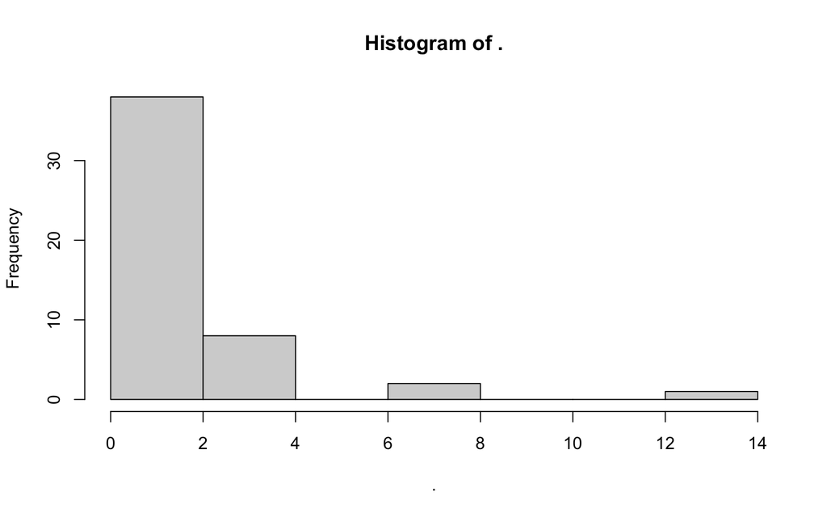

```r
US_hc$height %>% hist()
```

Using basic `plot()`function, we can visualize the distances and their hierarchical clustering groups.

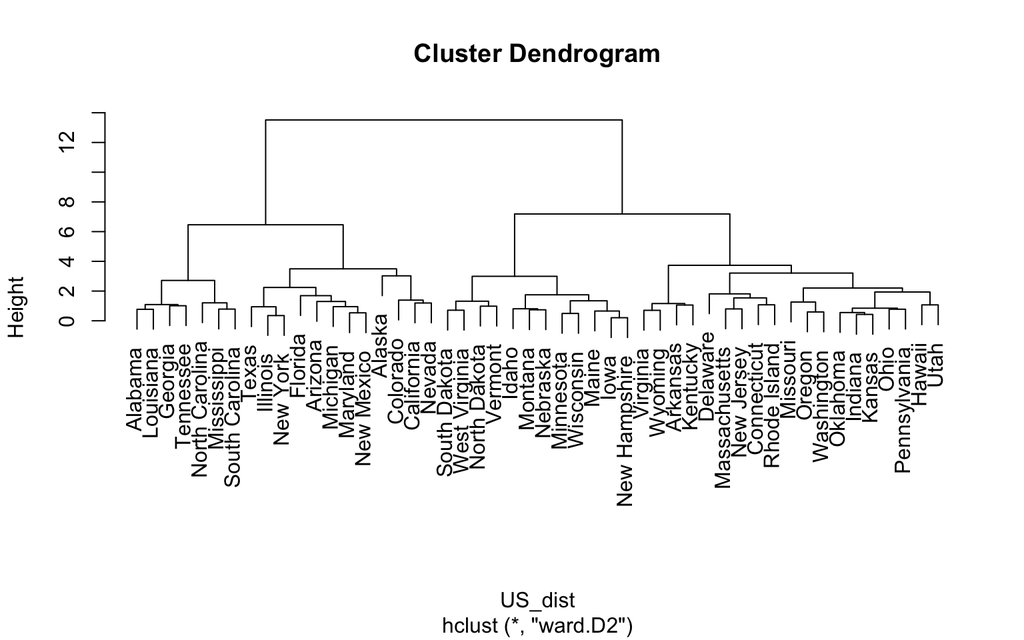

```r
base::plot(US_hc)
```

As the basic function is hard to manipulate (such as font sizes, font familiesm, etc.), we can use ggtree function from `ggtree` package

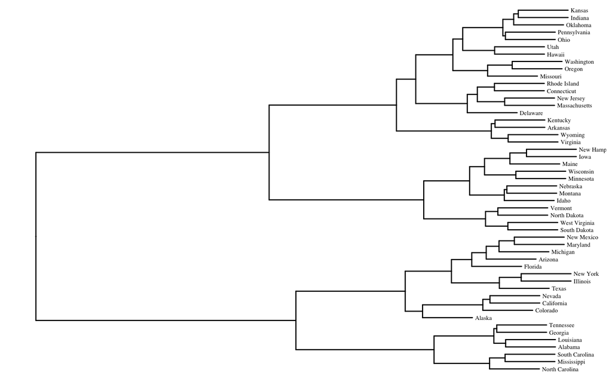

```r
library(BiocManager)
#BiocManager::install("ggtree")
library(ggtree)


ggtree(US_hc) +
  geom_tiplab(size = 2, family = "serif")
```

Similarly, we can calculate distances between characters as well, using `stringdist` package

```r
#install.packages("stringdist")

library(stringdist)
```

stringdist package and `stringdist::stringdist` can calculate the distances between *character* values.

For examples,

```r
stringdist("a", "a")
```

```
## [1] 0
```

```r
stringdist(c("Inha", "Induck", "BiologicalEngineering"),
           c("Inha", "Inha", "Inha"))
```

```
## [1]  0  4 20
```

`stringdist::stringdistmatrix` generates the matrix of the distance calculations.

```r
stringdistmatrix(c("Inha", "Induck", "BiologicalEngineering"),
           c("Inha", "Inha", "Inha"))
```

```
##      [,1] [,2] [,3]
## [1,]    0    0    0
## [2,]    4    4    4
## [3,]   20   20   20
```

Using this feature, we can calculate the distrance and generate the hierarchical clustuing of *TEXTS*

```r
text <- c("Chiiiiken","CCCCChicken","Chickkkken","Cowwww","Cooow", "CCCCow")

distancemodels <- stringdist::stringdistmatrix(text, text)

distancemodels
```

```
##      [,1] [,2] [,3] [,4] [,5] [,6]
## [1,]    0    6    4    8    8    8
## [2,]    6    0    7   10   10    7
## [3,]    4    7    0    9    9    9
## [4,]    8   10    9    0    3    4
## [5,]    8   10    9    3    0    3
## [6,]    8    7    9    4    3    0
```

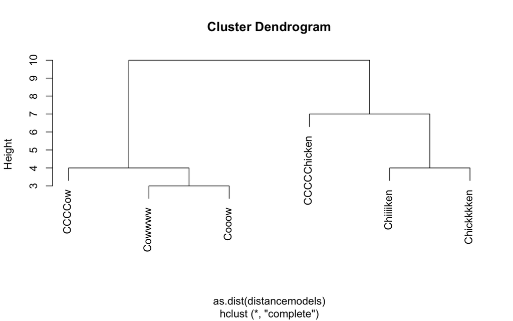

```r
rownames(distancemodels) <- text

hc <- hclust(as.dist(distancemodels))

plot(hc)
```

Or

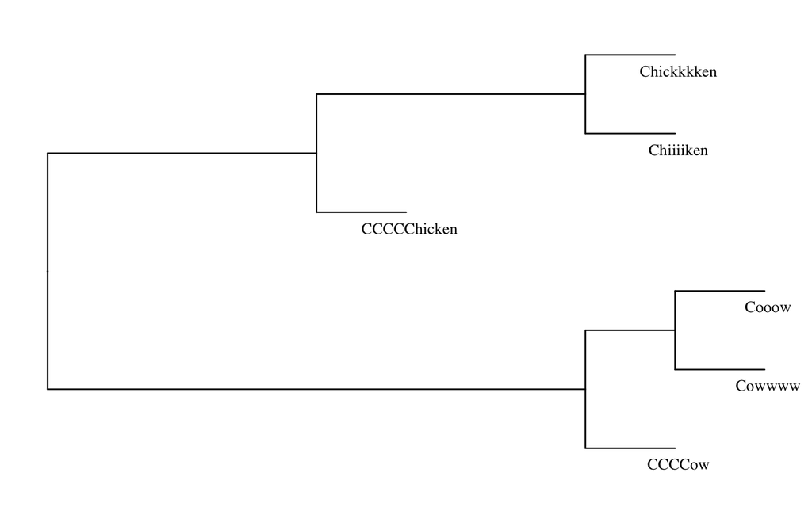

```r
ggtree(hc) +
  geom_tiplab(size = 4,
              family = "serif",
              hjust = 0.5, vjust = 2)
```

As same as the above example, Genomic sequences can be compared as below.

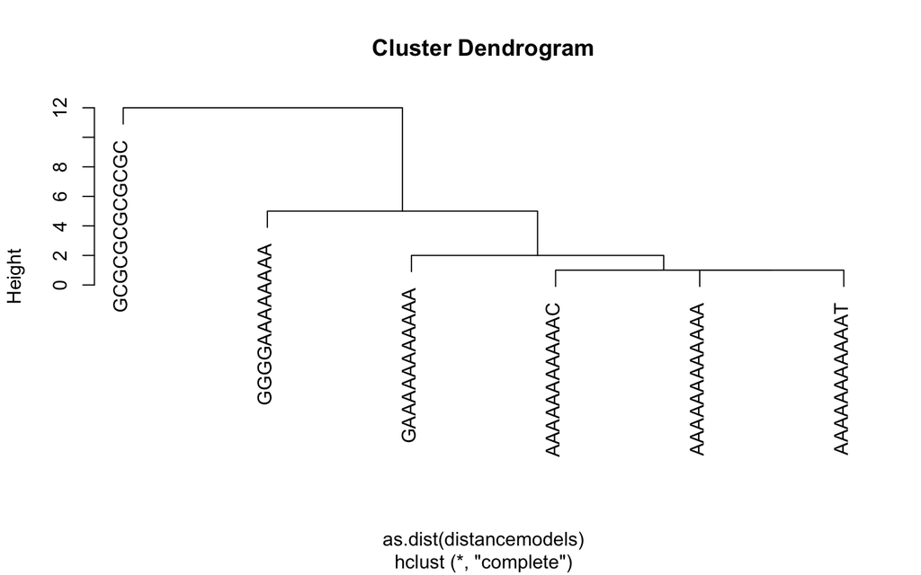

```r
text <- c("AAAAAAAAAAAA",
          "AAAAAAAAAAAT",
          "AAAAAAAAAAAC",
          "GAAAAAAAAAAA",
          "GGGGAAAAAAAA",
          "GCGCGCGCGCGC")

distancemodels <- stringdist::stringdistmatrix(text, text)
rownames(distancemodels) <- text

hc <- hclust(as.dist(distancemodels))
plot(hc)
```

If we have a data.frame of those sequences (their taxa names), we can construct a phylogenetic tree!

```r
rownames(distancemodels) <- c("E.coli 1",
                              "E.coli 2",
                              "E.coli 3",
                              "E.albertii",
                              "S. blattae",
                              "H.Sapiens")
distancemodels
```

```
##            [,1] [,2] [,3] [,4] [,5] [,6]
## E.coli 1      0    1    1    1    4   12
## E.coli 2      1    0    1    2    5   12
## E.coli 3      1    1    0    2    5   11
## E.albertii    1    2    2    0    3   11
## S. blattae    4    5    5    3    0   10
## H.Sapiens    12   12   11   11   10    0
```

This data is having just the new label names, with the same distance matrix.

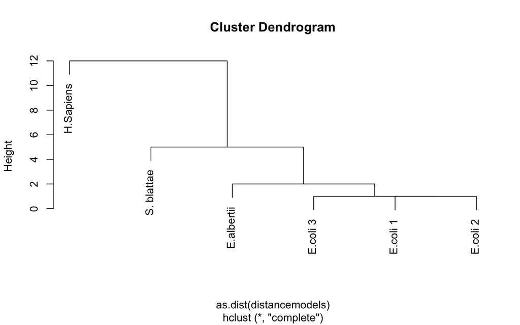

```r
hc <- hclust(as.dist(distancemodels))
plot(hc)
```

Else,

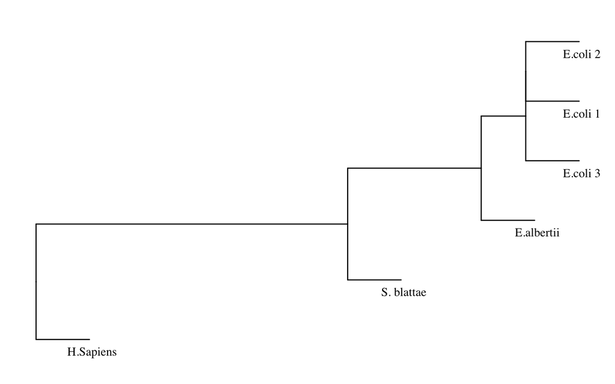

```r
ggtree(hc) +
  geom_tiplab(size = 4,
              family = "serif",
              hjust = 0.5, vjust = 2)
```

To get hiearchical cluster levels, you can use `cutree` function.

```r
cutree(hc, k = 1:6)
```

```
##            1 2 3 4 5 6
## E.coli 1   1 1 1 1 1 1
## E.coli 2   1 1 1 1 1 2
## E.coli 3   1 1 1 1 2 3
## E.albertii 1 1 1 2 3 4
## S. blattae 1 1 2 3 4 5
## H.Sapiens  1 2 3 4 5 6
```

You can rename the level values afterwards…